# Week 7: Spatial Point Pattern Analysis I

# Point Pattern Analysis

- set of $n$ point locations with recorded ``events’’, e.g., locations of trees, disease or crime incidents $S=\{s_1,\ldots,s_i,\ldots, s_n\}$
- point locations correspond to all possible events or to subsets of them
- attribute values also possible at same locations, e.g., tree diameter, magnitude of earthquakes (i.e.,marked point pattern) $W=\{w_1,\ldots,w_i,\ldots, w_n\}$

### Objectives:

- detect spatial clustering or repulsion, as opposed to complete randomness, of event locations (in space and time)
- if clustering detected, investigate possible relations with nearby ``sources’’

### Further

- analysis of point patterns over large areas should take into account distance distortions due to map projections
- boundaries of study area should not be arbitrary
- analysis of sampled point patterns can be misleading
- one-to-one correspondence between objects in study area and events in pattern

In this lecture, we will focus on the spatial statistical tools for cluster detection.

## Descriptive statistics

- Mean center
- Median center
- Standard distance
- For example:

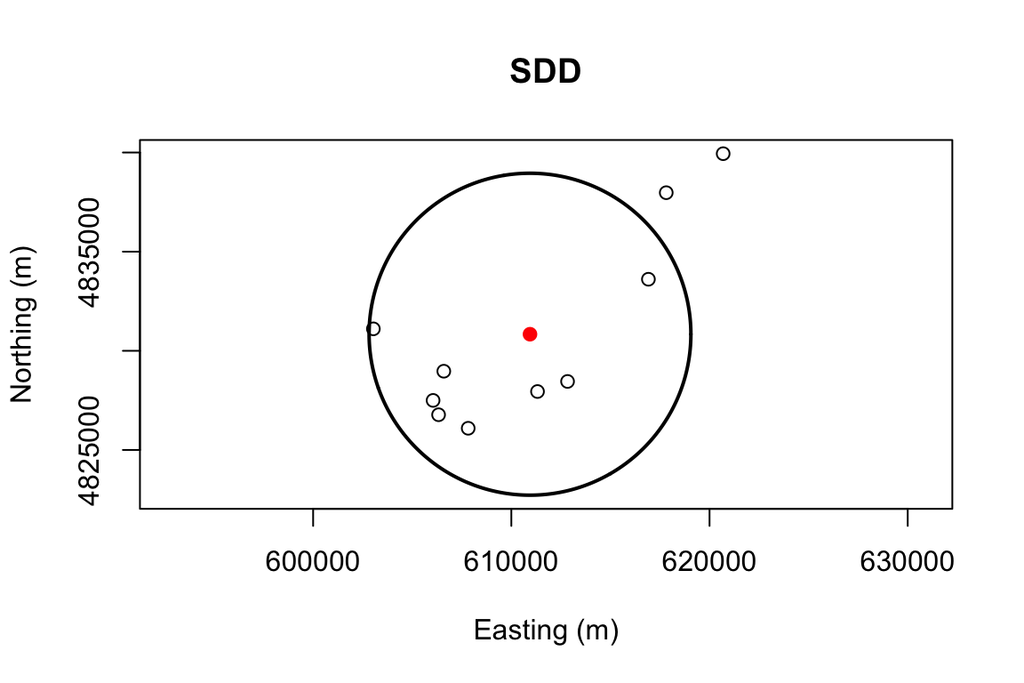

```r
library(aspace)
plot_sdd(plotnew=TRUE, plothv=FALSE, plotweightedpts=FALSE, plotpoints=TRUE, plotcentre=TRUE, titletxt="SDD", xaxis="Easting (m)",
yaxis="Northing (m)", sdd.col='black', centre.col='red')
```

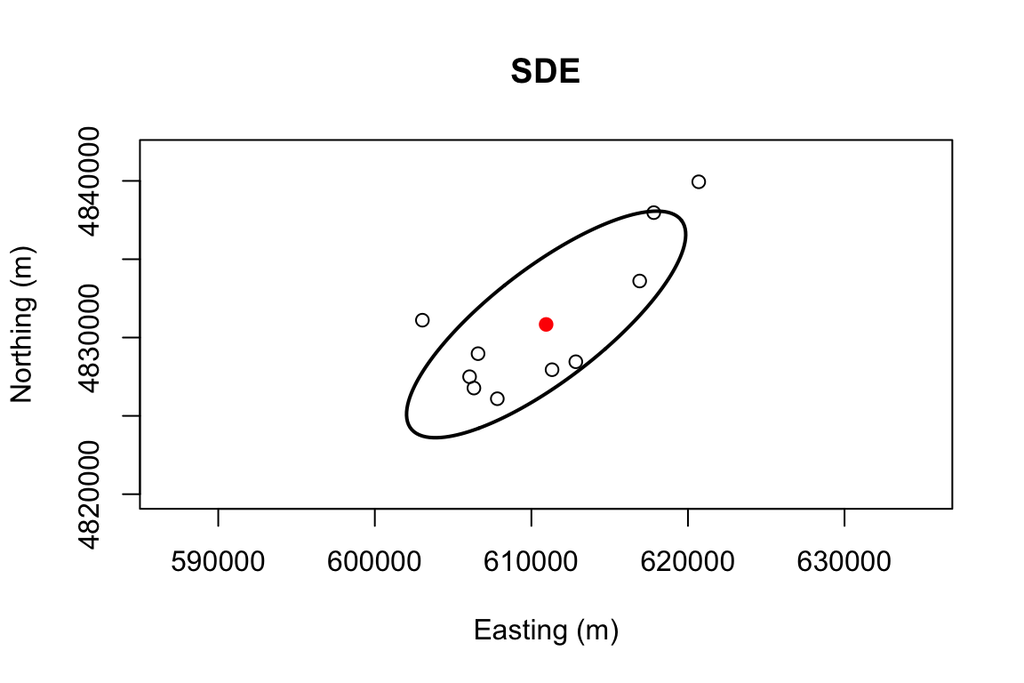

```r
plot_sde(plotnew=TRUE, plothv=FALSE, plotweightedpts=FALSE, plotpoints=TRUE, plotcentre=TRUE, titletxt="SDE", xaxis="Easting (m)",
yaxis="Northing (m)", sdd.col='blue', centre.col='red')
```

# Intensity-based methods (first-order)

### Quadrant count

- histogram in high dimensional spaces
- the starting point and size of the quadrant will affect the results

```r
data(bei)
X = bei
Q<-quadratcount(X,nx=6,ny=3)
plot(X, main='bei',pch = 20, cex = 0.5)
plot(Q,add=TRUE,cex=2, col='red')
quadrat.test(Q)

# investigate the effects of other covariates

Z <- bei.extra$grad
par(mfrow = c(3, 2))
par(mar=c(2,0,3,0) + 0.1)
plot(bei, pch=20, cex= 0.5, main='bei')
plot(Z, main='slope')
b <- quantile(Z, probs = (0:4)/4)
Zcut <- cut(Z, breaks = b, labels = 1:4)
V <- tess(image = Zcut)
plot(V, main = 'reclass of slope')
plot(bei, add = TRUE, pch=20, cex=0.5)
qb <- quadratcount(bei, tess = V)
plot(qb, col='white', main = 'quadrat based on reclass-ed slope')
plot(rhohat(bei, Z), main='intensity vs. slope')
```

[output not shown]

### kernel density estimation

- Based on quadrant method, $\hat{p}(s)=\frac{1}{N}\frac{\mbox{# in bin}}{\mbox{area of bin}} = \frac{k_b}{N*V_b}$, where $k_b$ is the number of points in bin $b$, and $V_b$ is the volume of $b$
- Parzen window: a region centered at each $s$ with length $h$. To find the number of points that fall within this region, we define a `kernel function`

$$K(u)=K(\frac{s-s_i}{h})= \left \{ \begin{array}{ll} 1 & \mbox{if |u| < 1/2};\\
0 & \mbox{o.w.} \end{array} \right.$$

Then the previous density can be written as $\hat{p}(s)= \frac{1}{N*h^d} \sum_{i=1}^{N}K(\frac{s-s_i}{h})$

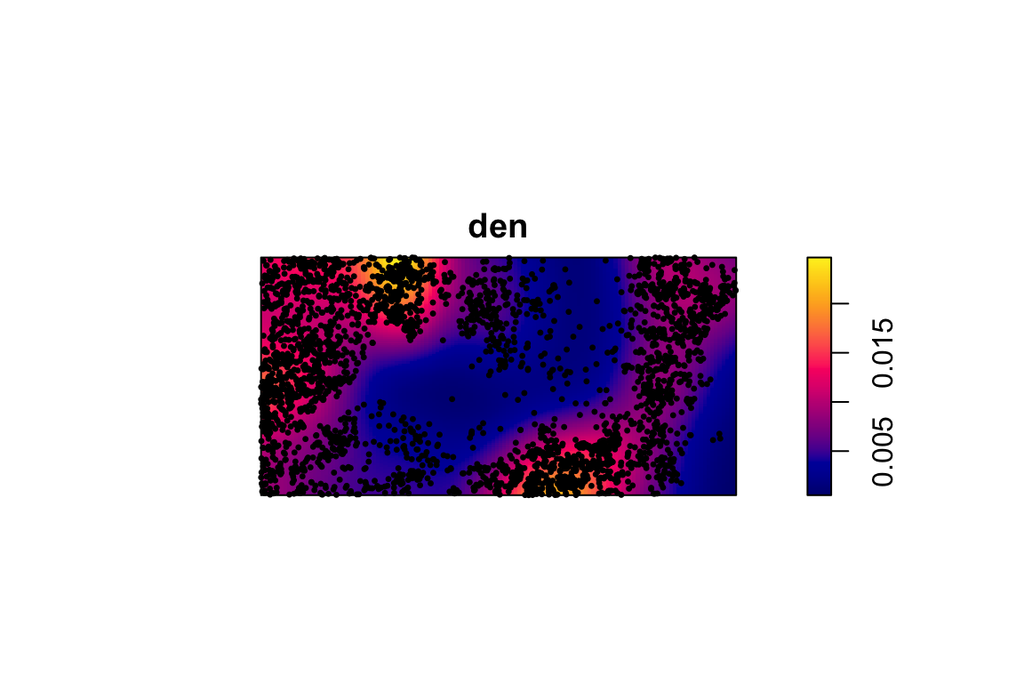

```r
library(spatstat)
X=bei
den=density(X, bw=70, main='density')
plot(den)
plot(X, add = TRUE, cex = 0.5, main='density', pch = 20)
```

```r
#persp(den)
```

Another example using Lubbock data

[figure not shown]

```r
library(maptools)
library(ggmap)
library(RgoogleMaps)

house<-readShapePoints("Data/HouseSaleLubbock.shp")
#check that my data contains the data you expect
head(house)
#get the coordinate of each house on sale
Lat<-house$Lat
Lon<-house$Lon
#check that the point pattern looks right by plotting it

lubbock=geocode('lubbock')

newmap <- GetMap(center = c(lubbock$lat, lubbock$lon), zoom = 12, destfile = "newmap.png", maptype = "roadmap")

PlotOnStaticMap(newmap, lat=Lat, lon=Lon, col='red')
```

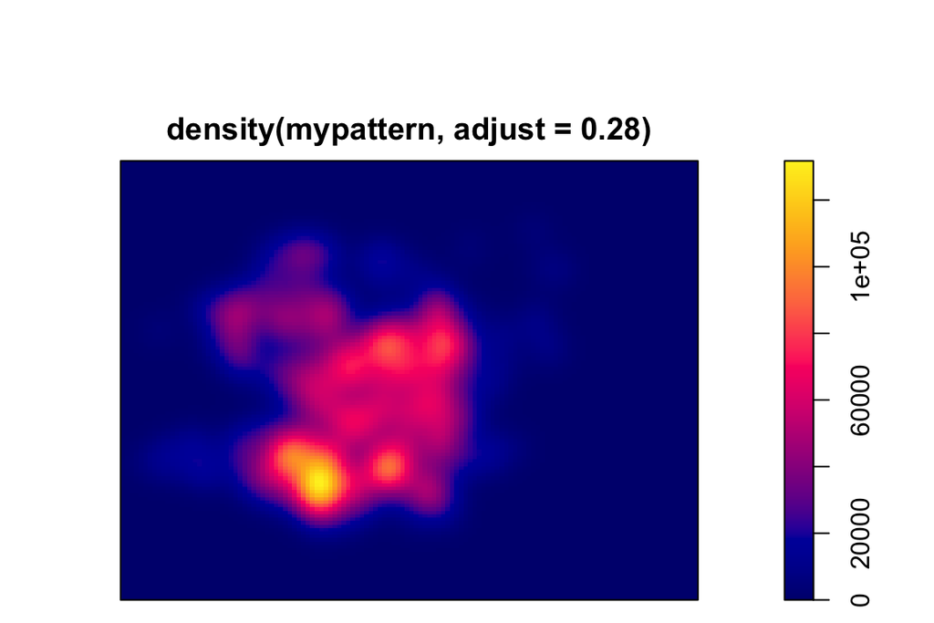

```r
#convert the data to a point pattern object
mypattern<-ppp(Lon,Lat, c(-102,-101.75), c(33.46,33.65))
#basic summary of the data
summary(mypattern)

#kernel density estimation map
plot(density(mypattern,adjust=0.28))
```

## Distance-based methods (second-order)

- $G}$ functions: sample cdf of nearest pair-wise distances between events.
- ${F}$ functions: sample cdf of nearest distances between arbitrary points and observations or empty space function.
- ${K}$ functions: ${K}(t)=\lambda^{-1}\mbox{E{number of events within distance t of an arbitrary event}}$, where $\lambda$ is the density of the study area. It actually represents the sample cdf of pair-wise distances normalized by area.

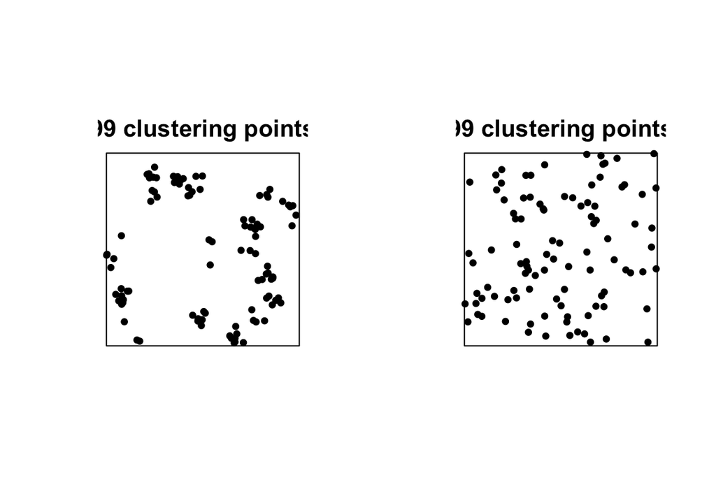

```r
library(Hmisc)
cluster <- rMatClust(20, 0.05, 4)
unif = runifpoint(cluster$n)

par(mfrow=c(1,2))
plot(cluster, main=paste(cluster$n, "clustering points"), pch = 20)
plot(unif, main=paste(cluster$n, "clustering points"), pch = 20)
```

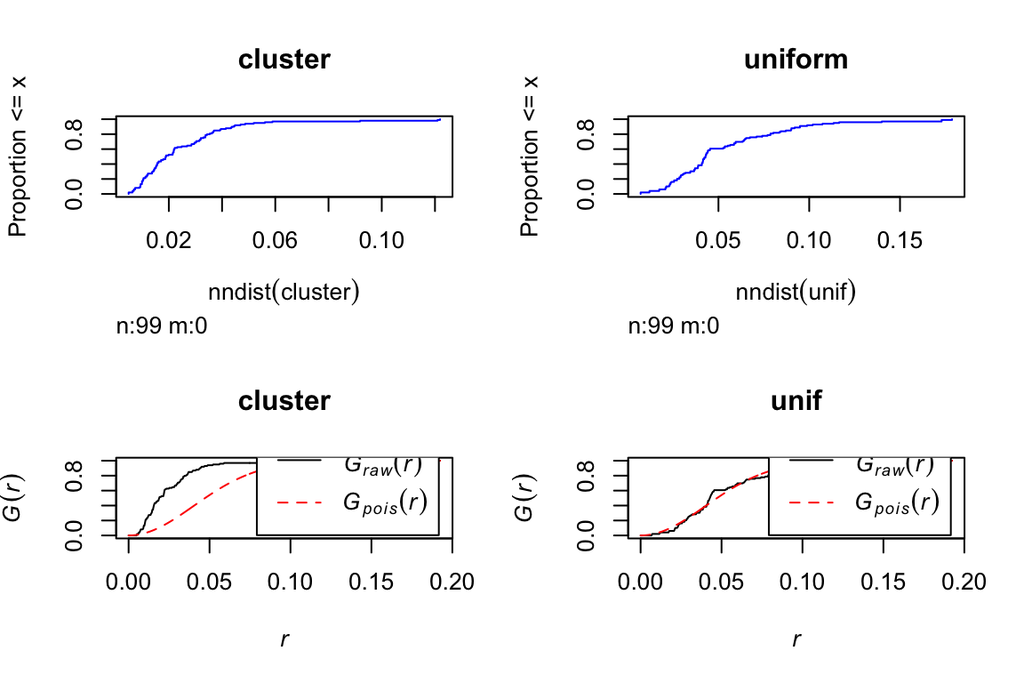

```r
par(mfrow=c(2,2))
Ecdf(nndist(cluster), main = 'cluster', breaks = 20, col='blue')
Ecdf(nndist(unif), main = 'uniform', breaks = 20,col='blue')

Gtest2<-Gest(cluster, correction="none")
plot(Gtest2, main='cluster')
Gtest<-Gest(unif, correction="none")
plot(Gtest, main='unif')
```

[figure not shown]

```r
#par(mfrow=c(1,2))
#pepper=runifpoint(10000)
#Ecdf(nndist(pepper, cluster),main='empty space function', breaks=20)
#plot(Fest(cluster, correction='none'))

par(mfrow=c(3,2))
Ecdf(pairdist(cluster), main='cluster CDF' )
Ecdf(pairdist(unif), main='uniform CDF')
plot(Kest(cluster, correction='none'))

plot(bei, cex=0.5)
Ktest<-Kest(bei, correction="none")
plot(Ktest)

Ltest<-Lest(bei, correction="none")
plot(Ltest)
```

## Complete spatial randomness

- yardstick, reference model that observed point patterns could be compared with, i.e., null hypothesis
- homogeneous Poisson point process}
- basic properties:
- the number of points falling in any region $A$ has a Poisson distribution with mean $\lambda|A|$
- given that there are $n$ points inside region $A$, the locations of these points are i.i.d. and uniformly distributed inside $A$
- the contents of two disjoint regions $A$ and $B$ are independent

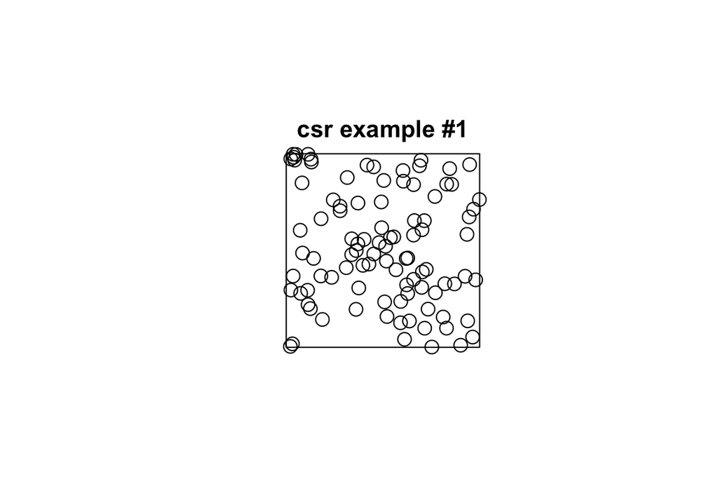

```r
plot(rpoispp(100), main='csr example #1', cex=1.5)
```

[figure not shown]

```r
#plot(rpoispp(100), main='csr example #2')
data(letterR)
#plot(rpoispp(100, win = letterR), main='csr example #3')
plot(rpoispp(100, win = letterR), main ='csr example #2', cex=1.5 )
```

### Quadrant testing for CSR

- partition study area $A$ into $L$ sub-regions (quadrats), $A_1, \ldots, A_L$
- count number of events $n(A_l)$ in each sub-region $A_l$
- Under the null hypothesis of CSR, the $n(A_l)$ are i.i.d. Poisson random variables with the same expected value -The Pearson $\chi^2$ goodness-of-fit test can be used

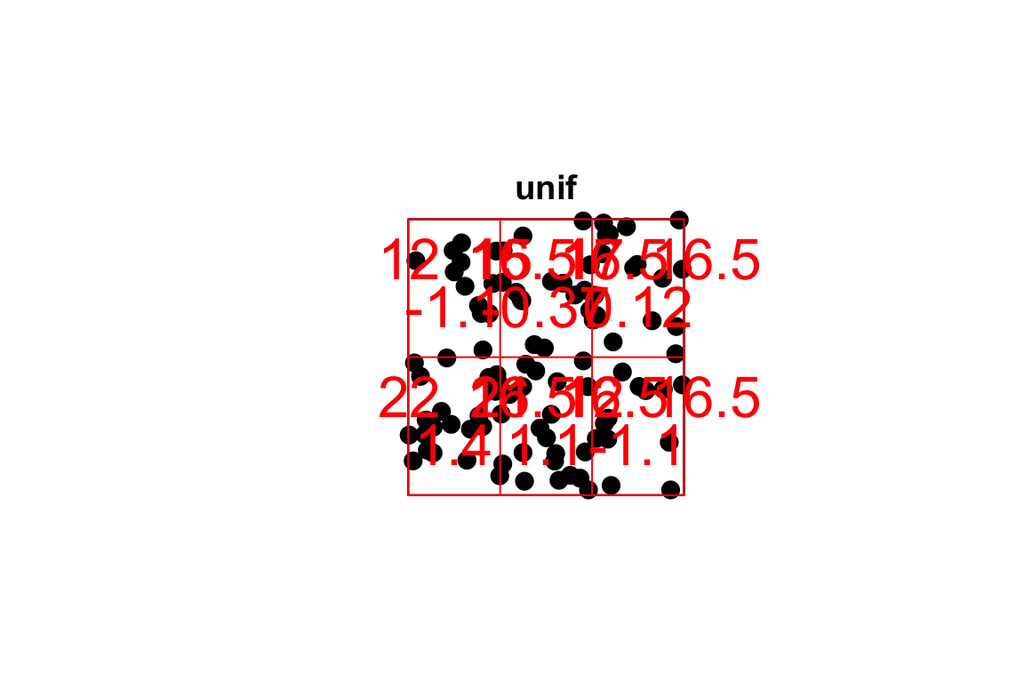

```r
M <- quadrat.test(unif, nx = 3, ny = 2)
plot(unif, cex=2, pch=20)
plot(M, add = TRUE, cex = 2, col='red')
```

### Distance-based function under CSR

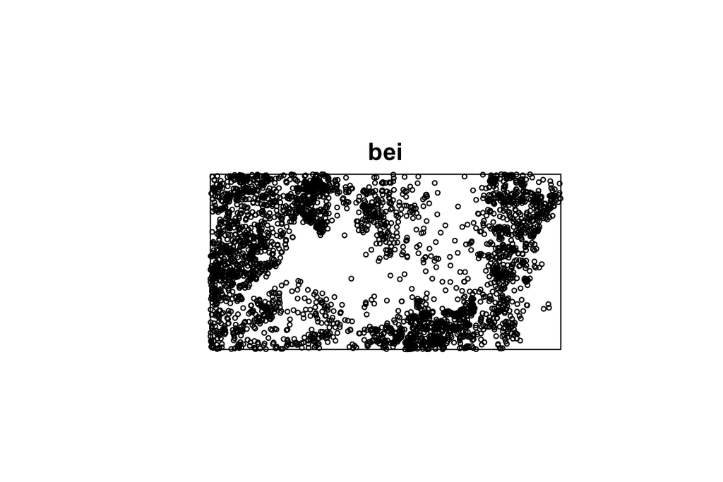

```r
plot(bei, cex=0.5)
```

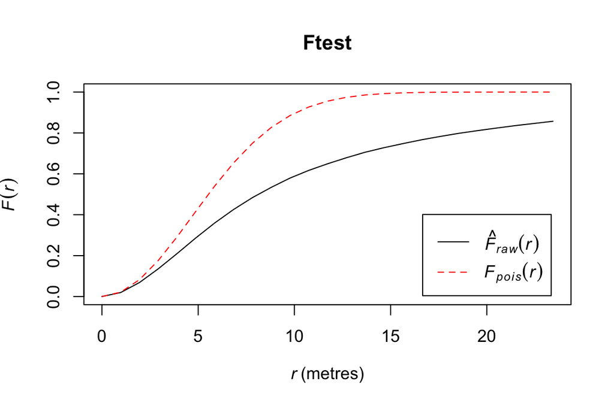

```r
Ftest<-Fest(bei, correction="none")
plot(Ftest)
```

### Monte Carlo test

- because of random variability, we will never obtain perfect agreement between sample functions (say the K function) with theoretical functions (the theoretical K functions), even with a completely random pattern

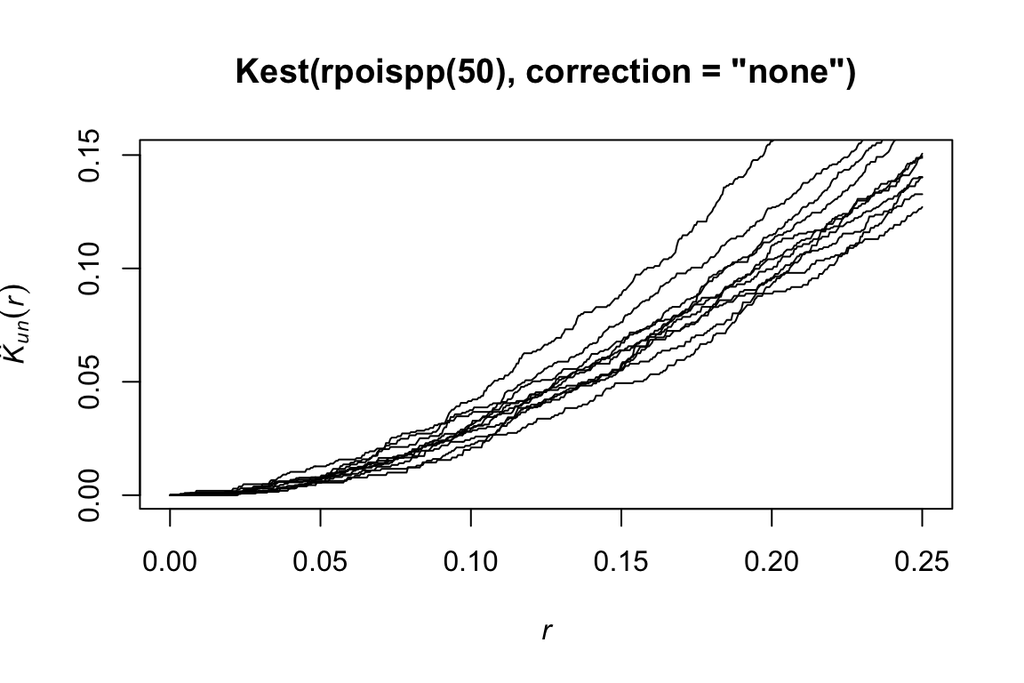

```r
plot(Kest(rpoispp(50), correction='none'),un~r)
for(i in 1:10){
plot(Kest(rpoispp(50), correction='none'),un~r, add=TRUE)
}
```

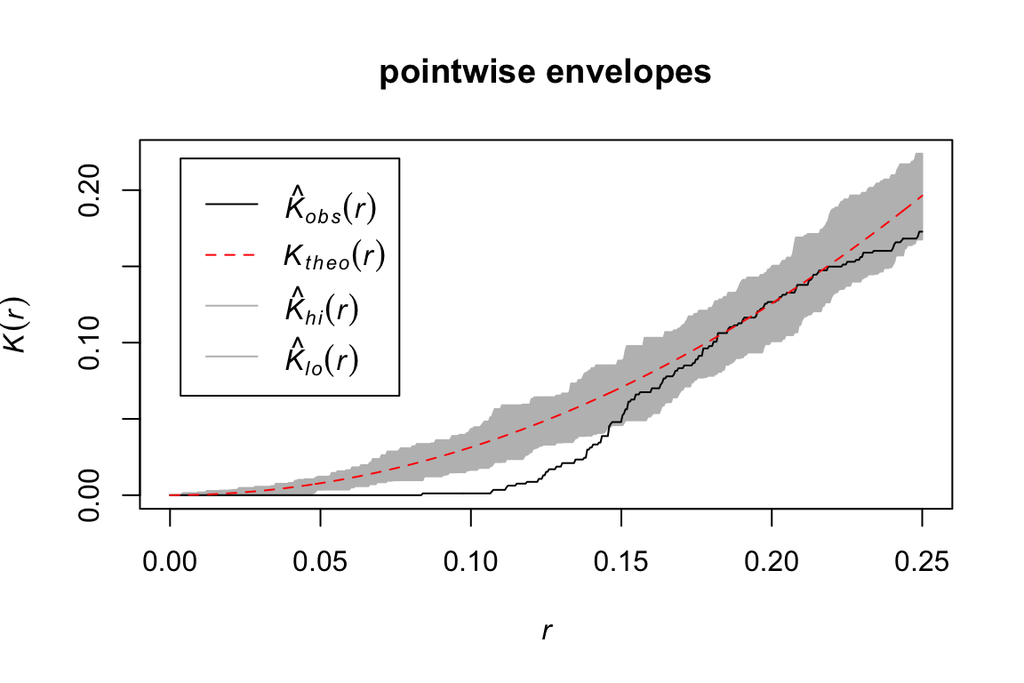

```r
data(cells)
monte2<-envelope(cells, Kest, nsim = 39, rank = 1)
plot(monte2, main = "pointwise envelopes")
```

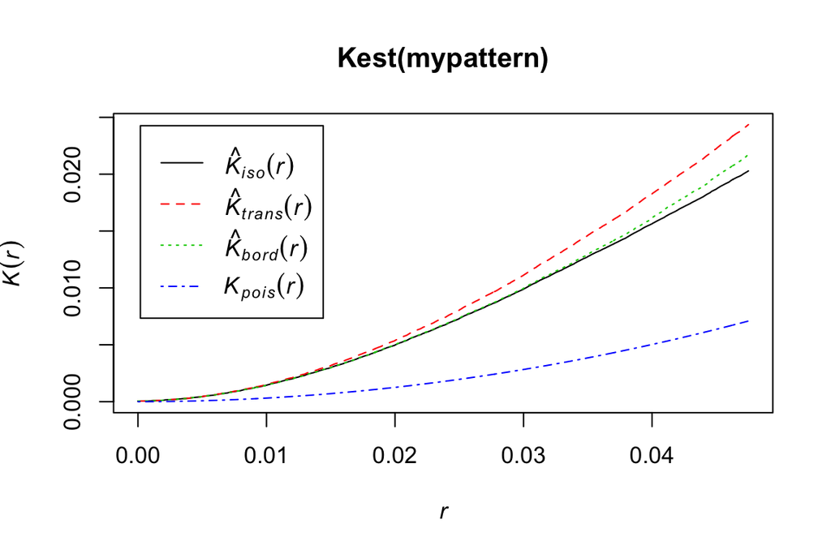

```r
# Now, test on the Lubbock house data

#Read the HouseSaleLubbock shapefile into R
#Ripley's K-function
plot(Kest(mypattern))
```

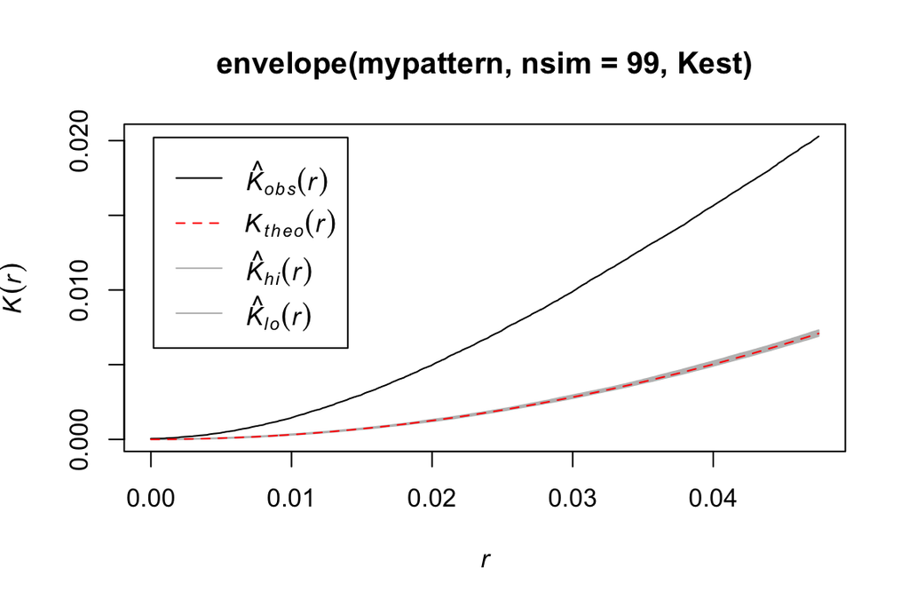

```r
#envelop of K-function
plot(envelope(mypattern,nsim=99,Kest))
```